# Test de independencia

# Test de Independencia

**Cargar librerías**

```r
library(dplyr)
library(ggplot2)
```

**Load the data**

```r
hd_data <- read.csv("data/Cleveland_hd.csv")
```

**Data processing**

```r
hd_pr <- hd_data %>%
  mutate(sex = as.factor(ifelse(sex == 0, "mujer", "hombre")),
         hd = ifelse(class > 0, 1, 0),
         hd_etiqueta = as.factor(ifelse(hd == 0, "No enfermedad", "Enfermedad")))  %>%
  relocate(c(hd, hd_etiqueta), .after = sex) %>%
  select(age:hd_etiqueta, trestbps, chol, thalach)
```

## Chi cuadrado

**Caso de una variable.** Ejemplo : moneda (legal) vs moneda trucada.

**Planteamiento de hipótesis :**  
H0: La muestra se ajusta a la distribución teórica.  
H1: La muestra no se ajusta a la distribución teórica.

```r
# Fair coin
n = 100
moneda <- sample(c("cara","cruz"), size = n, replace = T)
table(moneda)
```

```
## moneda
## cara cruz
##   51   49
```

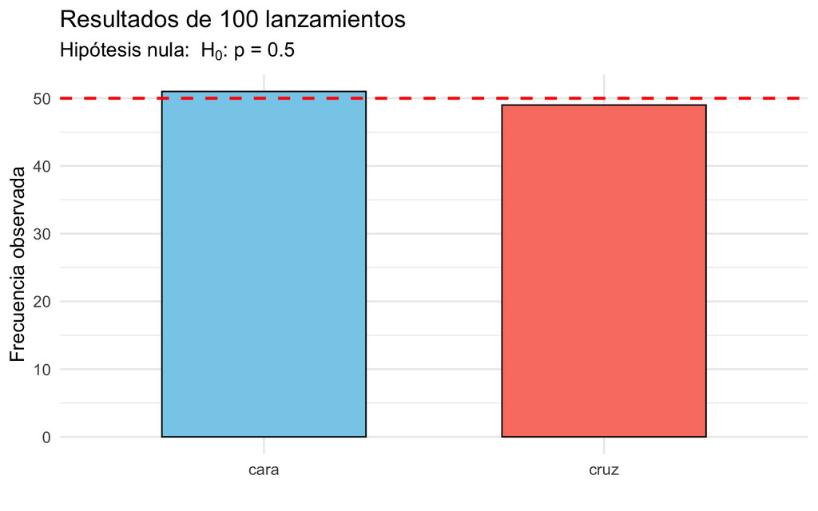

```r
# Dataviz for fair coin :
datos <- as.data.frame(table(moneda)) %>% #convierte la tabla en dataframe
  rename("res" = moneda, "freq" = Freq)

# dataViz
datos %>%
  ggplot(aes(x = res, y = freq, fill = res)) +
  geom_bar(stat = "identity", width = 0.6, color = "black") +
  geom_hline(yintercept = n/2, color = "red", linetype = "dashed", size = 1) +
  scale_fill_manual(values = c("skyblue", "salmon")) +
  labs(title = "Resultados de 100 lanzamientos",
       subtitle = expression("Hipótesis nula: " ~ H[0] * ": p = 0.5"),
       x = "",
       y = "Frecuencia observada") +
  theme_minimal(base_size = 14) +
  theme(legend.position = "none")
```

```r
# Statistical test
chisq.test(table(moneda))
```

```
##
##  Chi-squared test for given probabilities
##
## data:  table(moneda)
## X-squared = 0.04, df = 1, p-value = 0.8415
```

```r
# Rigged coin
n = 100000
t_moneda <- sample(c(0,1), n, replace = T, prob = c(0.6, 0.4))
table(t_moneda)
```

```
## t_moneda
##     0     1
## 60150 39850
```

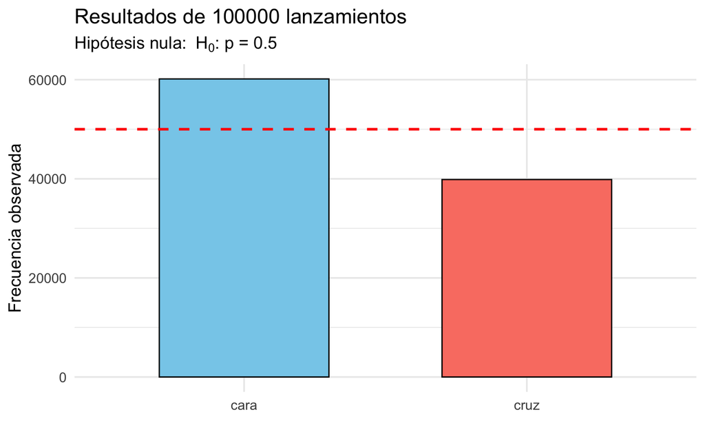

```r
# Dataviz for rigged coin :
datos <- as.data.frame(table(t_moneda)) %>% #convierte la tabla en dataframe
  rename("res" = t_moneda, "freq" = Freq) %>%
  mutate(res = ifelse(res == 0, "cara", "cruz"))

# dataViz
ggplot(datos, aes(x = res, y = freq, fill = res)) +
  geom_bar(stat = "identity", width = 0.6, color = "black") +
  geom_hline(yintercept = n/2, color = "red", linetype = "dashed", size = 1) +
  scale_fill_manual(values = c("skyblue", "salmon")) +
  labs(title = "Resultados de 100000 lanzamientos",
       subtitle = expression("Hipótesis nula: " ~ H[0] * ": p = 0.5"),
       x = "",
       y = "Frecuencia observada") +
  theme_minimal(base_size = 14) +
  theme(legend.position = "none")
```

```r
# Statistical test
chisq.test(table(t_moneda))
```

```
##
##  Chi-squared test for given probabilities
##
## data:  table(t_moneda)
## X-squared = 4120.9, df = 1, p-value < 2.2e-16
```

### Dos variables

Ejemplo : ¿hay asociación entre el sexo (variable cualitativa) y la condición sano/enfermo (variable cualitativa) ?

**Planteamiento de hipótesis :**  
H0: There is no association between sex and hd (= entre hd y sex). Sex categories are independent of hd category levels.

H1: There is association between sex and hd (= entre hd y sex). Sex categories are not independent of hd category levels.

**Visualización datos**

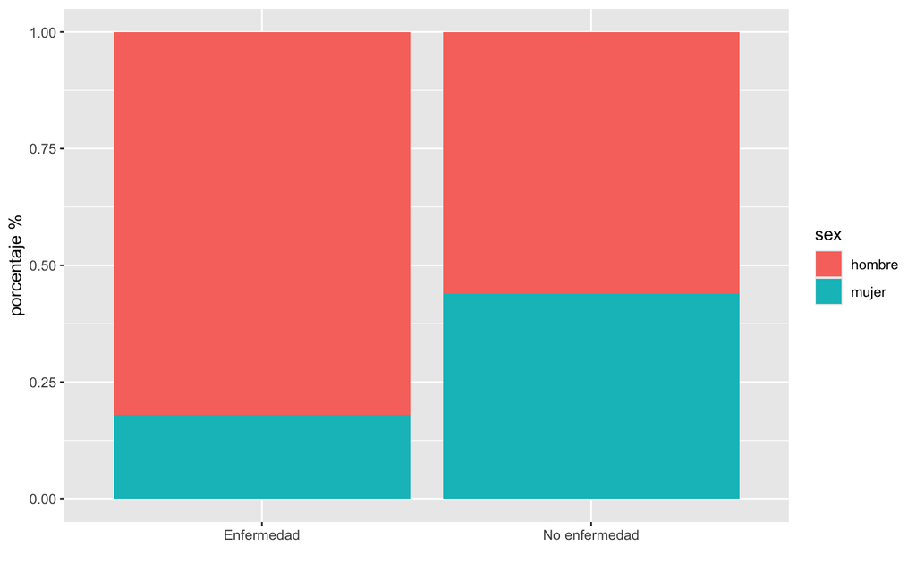

```r
# obtener valores de la variable 'hd'
vals_hd <- hd_pr %>% pull(hd_etiqueta)

# obtener valores de la variable 'sex'
vals_sex <- hd_pr %>% pull(sex)

hd_pr %>%
  ggplot(aes(x = hd_etiqueta, fill = sex)) +
  geom_bar(position = "fill") +
  labs(x = "", y= "porcentaje %")
```

```r
# test de independencia
hd_by_sex <-  chisq.test(vals_sex, vals_hd)
hd_by_sex
```

```
##
##  Pearson's Chi-squared test with Yates' continuity correction
##
## data:  vals_sex and vals_hd
## X-squared = 22.043, df = 1, p-value = 2.667e-06
```

## *t* test

El t test se realiza cuando tenemos una variable dependiente y una variable independiente categórica con dos grupos.

Examina la variable ‘chol’ entre los grupos enfermedad/sanos.

```r
condition <- hd_pr %>%
  pull(hd_etiqueta)

colesterol <- hd_pr %>%
  pull(chol)

chol_by_condition <- t.test(colesterol ~ condition)
chol_by_condition
```

```
##
##  Welch Two Sample t-test
##
## data:  colesterol by condition
## t = 1.4924, df = 298.64, p-value = 0.1366
## alternative hypothesis: true difference in means is not equal to 0
## 95 percent confidence interval:
##  -2.815018 20.484170
## sample estimates:
##    mean in group Enfermedad mean in group No enfermedad
##                    251.4748                    242.6402
```

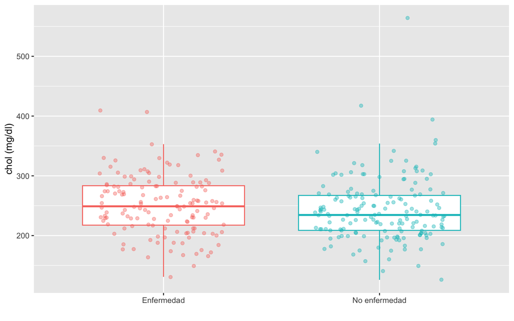

```r
hd_pr %>%
  ggplot(aes(x = hd_etiqueta, y = chol, color = hd_etiqueta)) +
  geom_boxplot(show.legend = FALSE, outlier.shape = NA) +
  geom_jitter(width = 0.3, alpha = 0.4) +
  labs(x = "", y = "chol (mg/dl)") +
  theme(legend.position = "none")
```

### Ejercicios :

**1. Examina la variable ‘age’ entre los grupos enfermedad/sanos**

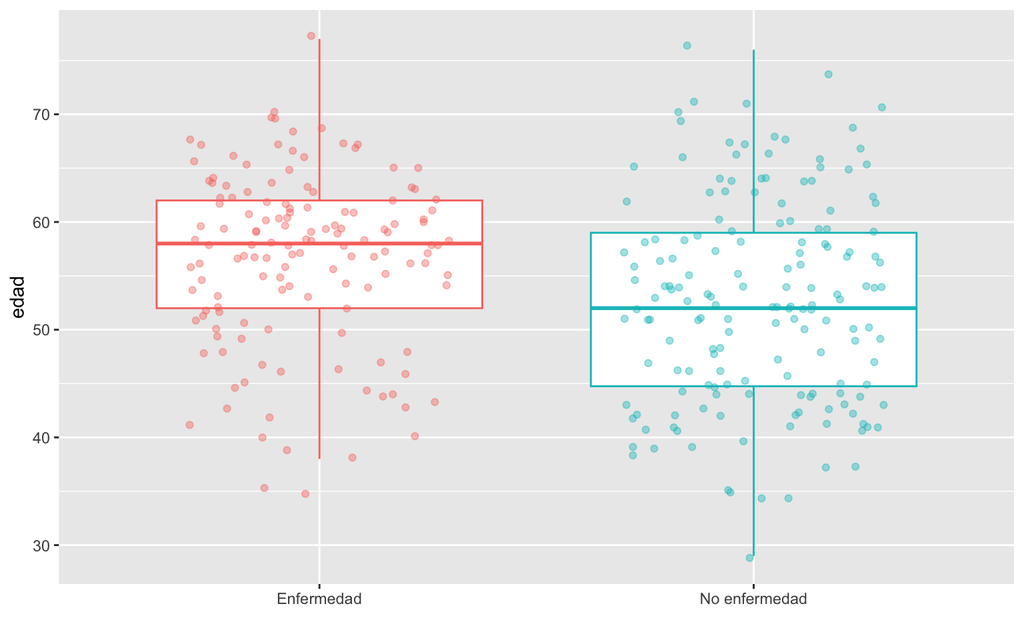

```r
age <- hd_pr %>% pull(age)

hd_pr %>%
  ggplot(aes(x = hd_etiqueta, y = age, col = hd_etiqueta)) +
  geom_boxplot(show.legend = FALSE, outlier.shape = NA) +
  geom_jitter(width = 0.3, alpha = 0.4) +
  labs(x = "", y = "edad") +
  theme(legend.position = "none")
```

```r
age_by_condition <- t.test(age ~ condition )

print(age_by_condition)
```

```
##
##  Welch Two Sample t-test
##
## data:  age by condition
## t = 4.0303, df = 300.93, p-value = 7.061e-05
## alternative hypothesis: true difference in means is not equal to 0
## 95 percent confidence interval:
##  2.067682 6.013385
## sample estimates:
##    mean in group Enfermedad mean in group No enfermedad
##                    56.62590                    52.58537
```

**2. Examina la variable ‘thalach’ entre los grupos enfermedad/sanos**

[figure not shown]

```r
tension <- hd_pr %>% pull(thalach)

hd_pr %>%
  ggplot(aes(x = hd_etiqueta, y = age, col = hd_etiqueta)) +
  geom_boxplot(show.legend = FALSE, outlier.shape = NA) +
  geom_jitter(width = 0.3, alpha = 0.4) +
  labs(x = "", y = "maximum heart rate") +
  theme(legend.position = "none")
```

```r
thalach_by_condition <- t.test(tension ~ condition )

print(thalach_by_condition)
```

```
##
##  Welch Two Sample t-test
##
## data:  tension by condition
## t = -7.8579, df = 272.27, p-value = 9.106e-14
## alternative hypothesis: true difference in means is not equal to 0
## 95 percent confidence interval:
##  -23.90912 -14.32900
## sample estimates:
##    mean in group Enfermedad mean in group No enfermedad
##                     139.259                     158.378
```

**3. Examina la variable ‘trestbps’ entre los grupos enfermedad/sanos**

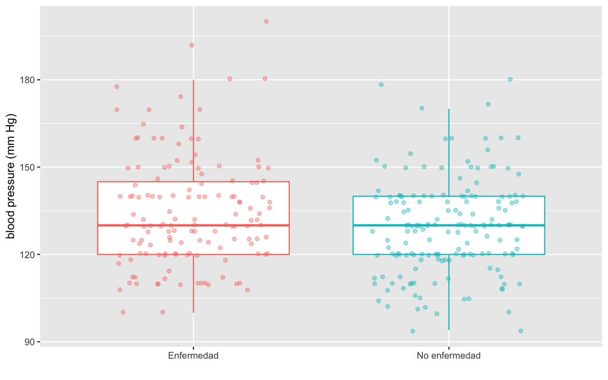

```r
bps <- hd_pr %>% pull(trestbps)

hd_pr %>%
  ggplot(aes(x = hd_etiqueta, y = trestbps, col = hd_etiqueta)) +
  geom_boxplot(show.legend = FALSE, outlier.shape = NA) +
  geom_jitter(width = 0.3, alpha = 0.4) +
  labs(x = "", y = "blood pressure (mm Hg)") +
  theme(legend.position = "none")
```

```r
bps_by_condition <- t.test(bps ~ condition )

print(bps_by_condition)
```

```
##
##  Welch Two Sample t-test
##
## data:  bps by condition
## t = 2.6152, df = 274.64, p-value = 0.009409
## alternative hypothesis: true difference in means is not equal to 0
## 95 percent confidence interval:
##  1.314915 9.321775
## sample estimates:
##    mean in group Enfermedad mean in group No enfermedad
##                    134.5683                    129.2500
```

¿ Las medias de los grupos son/no son diferentes ?

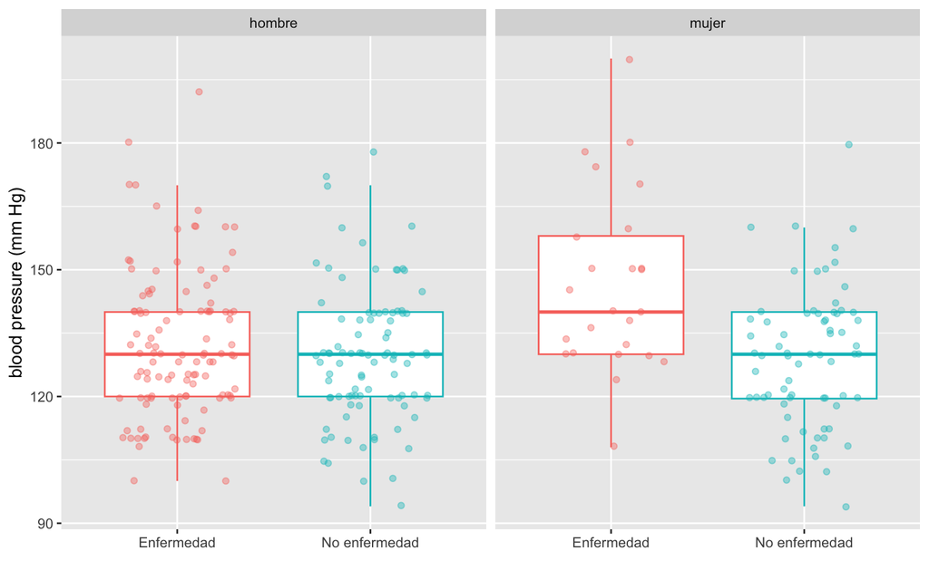

```r
hd_pr %>%
  ggplot(aes(x = hd_etiqueta, y = trestbps, col = hd_etiqueta)) +
  geom_boxplot(show.legend = FALSE, outlier.shape = NA) +
  geom_jitter(width = 0.3, alpha = 0.4) +
  labs(x = "", y = "blood pressure (mm Hg)") +
  theme(legend.position = "none") +
  facet_wrap(~ sex)
```

**4. Examina la variable ‘chol’ entre los grupos hombre/mujer**

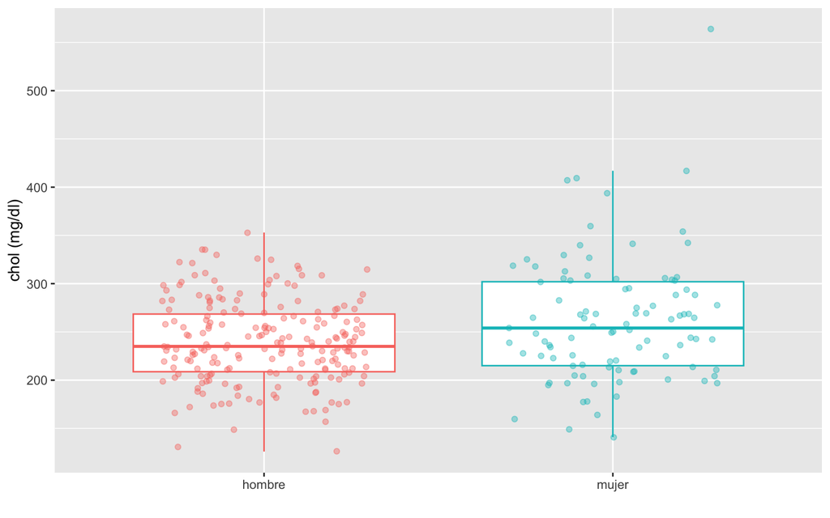

```
##
##  Welch Two Sample t-test
##
## data:  chol by sex
## t = -3.0643, df = 136.37, p-value = 0.002631
## alternative hypothesis: true difference in means is not equal to 0
## 95 percent confidence interval:
##  -36.445477  -7.855795
## sample estimates:
## mean in group hombre  mean in group mujer
##             239.6019             261.7526
```

**5. Examina la variable ‘trestbps’ entre los grupos hombre/mujer**

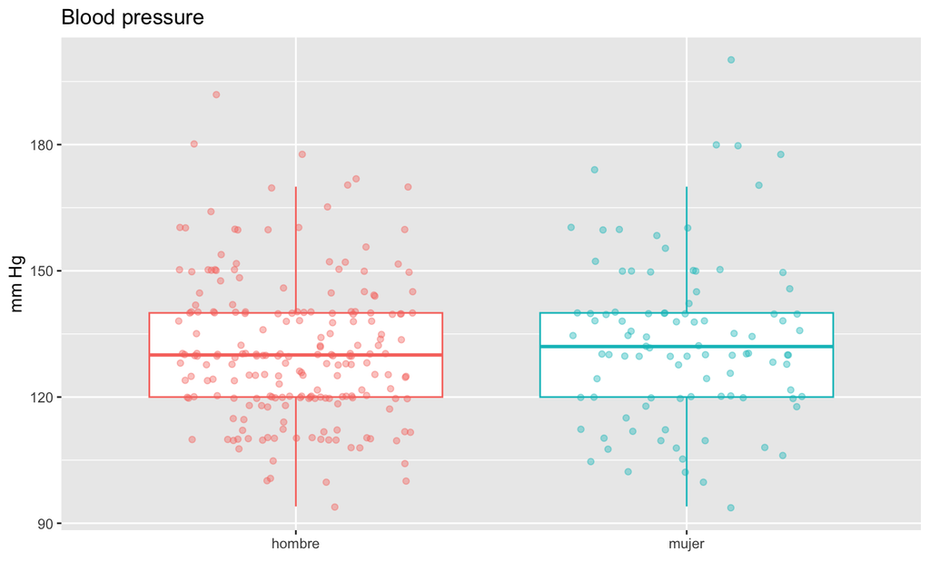

```
##
##  Welch Two Sample t-test
##
## data:  hd_pr$trestbps by hd_pr$sex
## t = -1.0622, df = 165.36, p-value = 0.2897
## alternative hypothesis: true difference in means is not equal to 0
## 95 percent confidence interval:
##  -6.939856  2.084686
## sample estimates:
## mean in group hombre  mean in group mujer
##             130.9126             133.3402
```

**6. Examina la variable ‘trestbps’ entre los grupos hombre/mujer ENFERMOS**

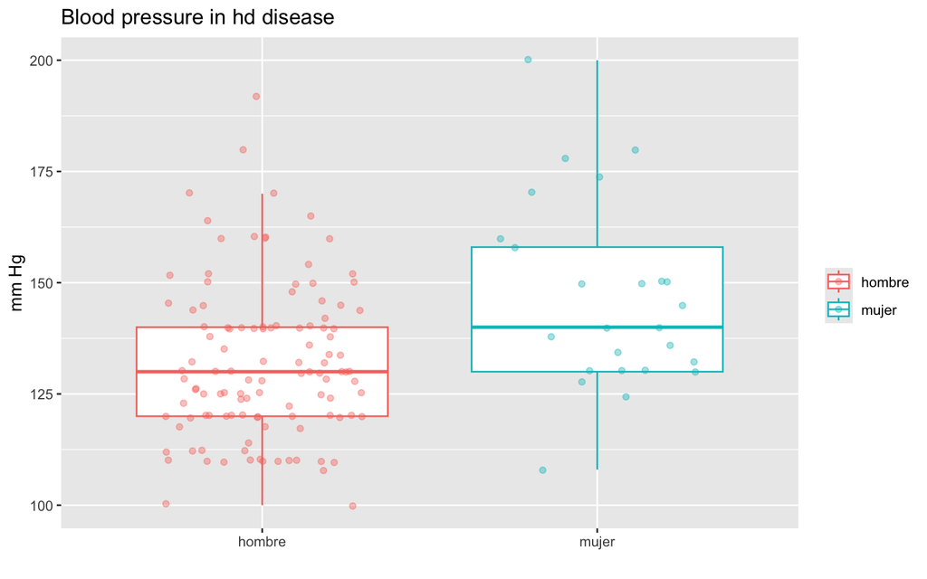

```
##
##  Welch Two Sample t-test
##
## data:  enfermedad$trestbps by enfermedad$sex
## t = -3.2448, df = 31.365, p-value = 0.002792
## alternative hypothesis: true difference in means is not equal to 0
## 95 percent confidence interval:
##  -23.886672  -5.453679
## sample estimates:
## mean in group hombre  mean in group mujer
##             131.9298             146.6000
```

**7. Examina la variable ‘thalach’ entre los grupos hombre/mujer**

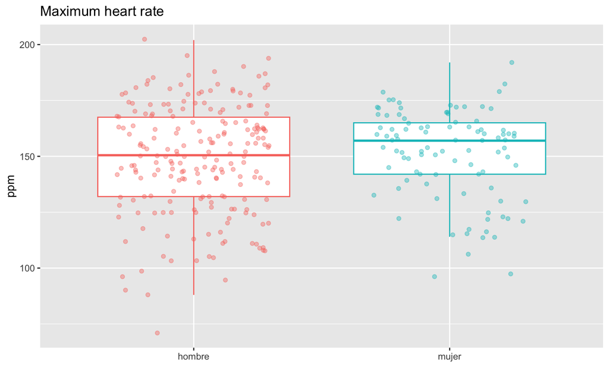

```
##
##  Welch Two Sample t-test
##
## data:  hd_pr$thalach by hd_pr$sex
## t = -0.90442, df = 223.85, p-value = 0.3667
## alternative hypothesis: true difference in means is not equal to 0
## 95 percent confidence interval:
##  -7.572564  2.808276
## sample estimates:
## mean in group hombre  mean in group mujer
##             148.8447             151.2268
```

**8. Examina la variable ‘thalach’ entre los grupos hombre/mujer ENFERMOS**

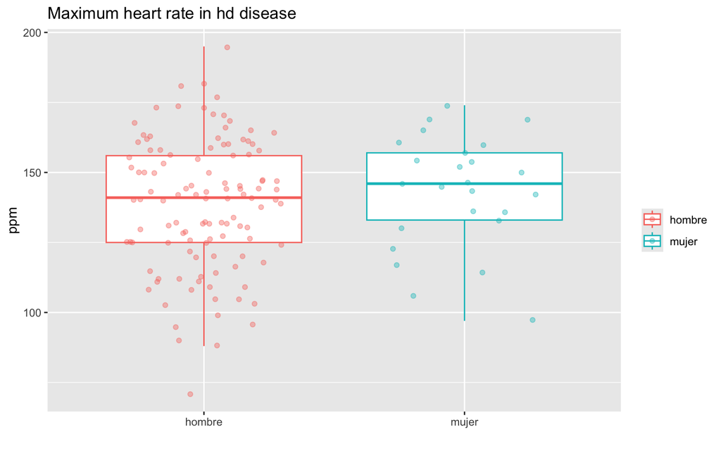

```
##
##  Welch Two Sample t-test
##
## data:  enfermedad$thalach by enfermedad$sex
## t = -1.039, df = 39.072, p-value = 0.3052
## alternative hypothesis: true difference in means is not equal to 0
## 95 percent confidence interval:
##  -14.015402   4.502419
## sample estimates:
## mean in group hombre  mean in group mujer
##             138.4035             143.1600
```